# Analisi delle vendite di console e di videogiochi

12/09/2023

## Dataset utilizzati

**[Sales of Video Games](https://www.kaggle.com/datasets/arslanali4343/sales-of-video-games)**

- 16600 righe e 11 colonne
- Contiene i dati piu’ rilevanti per ogni videogioco, dal 1980 al 2016, e le vendite totali nelle varie aree geografiche

**[Best-selling gaming consoles](https://www.kaggle.com/datasets/tayyarhussain/best-selling-game-consoles-of-all-time)**

- 51 righe e 7 colonne
- Contiene le informazioni principali e le vendite totali nel mondo per ogni console, dal 1975 al 2023.

## Le domande che mi sono posto

1. Quali sono i tipi di console più venduti?
   - Esiste un tipo dominante che supera costantemente gli altri?
2. Quali sono i generi di videogiochi più venduti nelle varie aree geografiche?
3. Esiste una relazione tra le vendite di console e di videogiochi?
   - Si possono individuare dei cluster?
4. Le vendite dei videogiochi sono influenzate dalla piattaforma in cui sono venduti?

## Quali sono i principali tipi di console?

- **Home**  
  Sono le console fisse, collegate a una TV o a un monitor.
- **Handheld**  
  Sono console dotate di una prorpia batteria, che ne consente l’utilizzo in qualsiasi luogo.
- **Dedicated**  
  Sono console in cui sono disponibili soltanto dei giochi pre-installati dal costruttore.
- **Home console add-on**  
  Sono dei device che ampliano le funzionalità di una console o che permettono un’esperienza di gioco più immersiva.
- **Hybrid**  
  Sono console che fondono, in un unico dispositivo, le caratteristiche delle console domestiche e portatili.

## I tipi di console più venduti

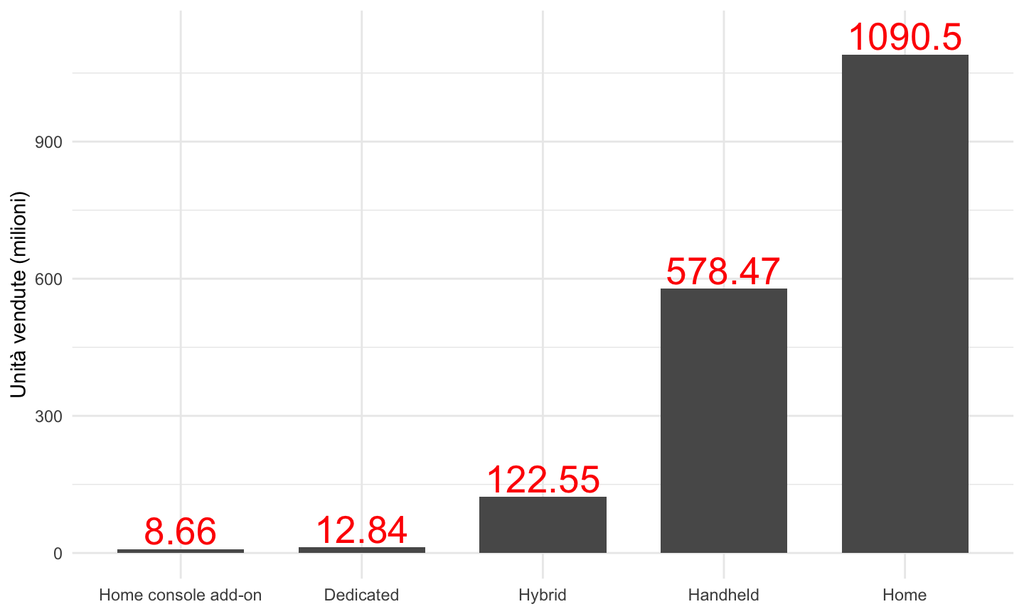

## I generi di videogiochi più venduti

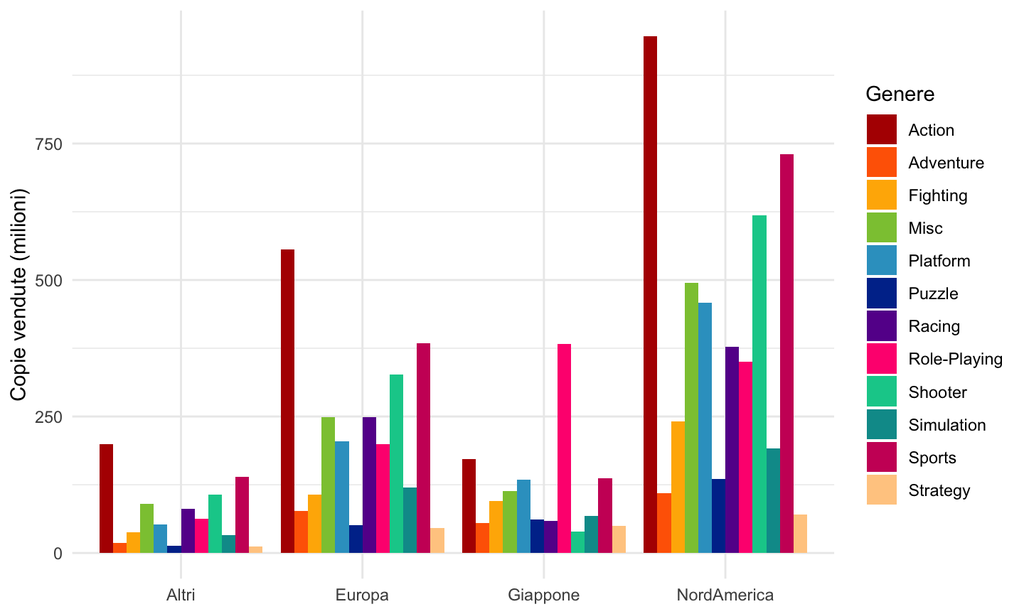

## Relazione tra le vendite di console e di videogiochi

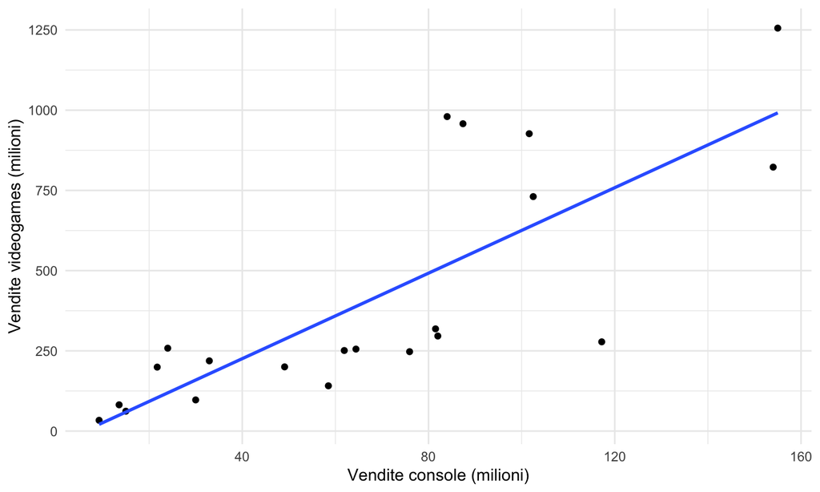

## I cluster individuati

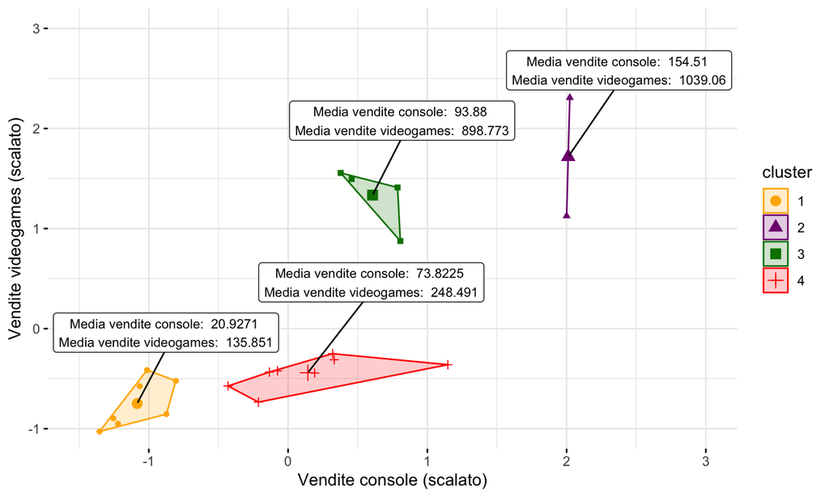

## L’influenza della piattaforma sulle vendite dei videogiochi

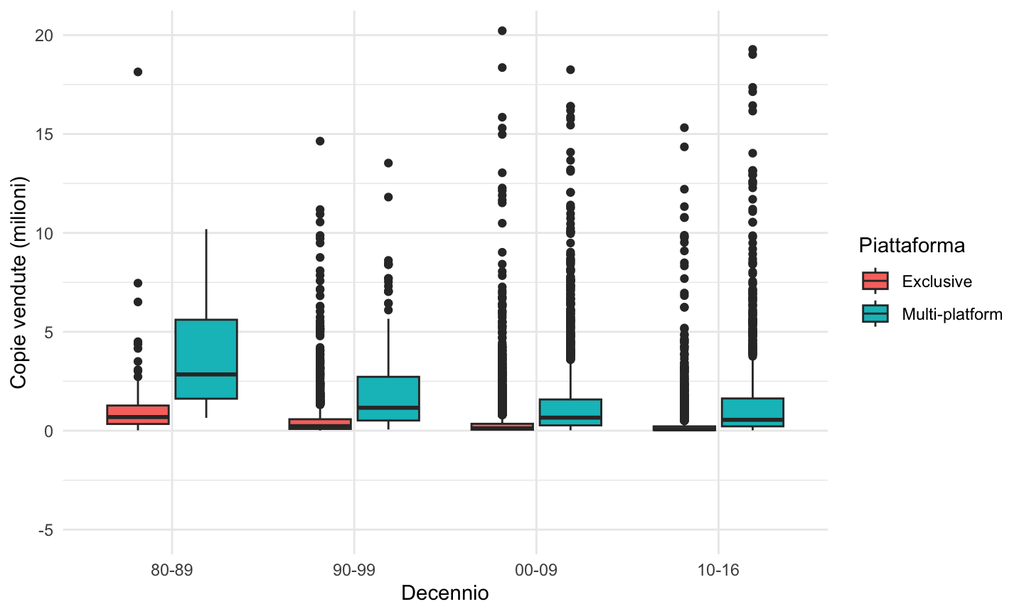

## Conclusioni

Dai grafici ottenuti abbiamo ricavato i seguenti risultati:

- Le home console sono le più vendute.
- Solamente in Giappone si registra un trend di vendite di videogiochi, in base al genere, diverso dal resto del mondo.
- Una relazione tra le vendite di console e di videogiochi esiste e ha un andamento lineare.
- Dal 1980 al 2016 le vendite mediane dei videogiochi multi-piattaforma si sono sempre più pareggiate a quelle dei titoli esclusivi, mantenendo, però, il vantaggio su questi ultimi.